# Supplemental Information: The Effects of Electromagnetic Articulography Sensors on Speech in Individuals with and without Dysarthria

Author

Austin Thompson<sup>1</sup>, Micah Hirsch<sup>2</sup>, and Yunjung Kim<sup>3</sup>

Abstract

1. Department of Communication Sciences and Disorders, University of Houston
2. Department of Speech, Language, and Hearing Sciences, Boston University
3. School of Communication Science and Disorders, Florida State University

**Corresponding Author**:  
Austin Thompson, PhD, CCC-SLP  
athomp27@central.uh.edu

# Supplemental Information

Although group, sex, age, and trial order effects within the Before Sensors time point were not the primary focus of this study, their inclusion in our models as interaction terms (Group × Time Point) or covariates (sex, age, trial order) allowed us to examine these variables.

**Group Effects.** PwPD demonstrated robustly smaller AAVSs (β = -.29, pd = 100%, CI = [-.48, -.08]) compared to control speakers at the baseline Before Sensors condition, after adjusting for age, sex, and articulation rate. Conversely, PwPD and control speakers showed comparable articulation rates (β = .04, pd = 57%, CI = [-.39, .46]), M1 (/s/: β = -.30, pd = 83%, CI = [-.93, .31]; /ʃ/: β = -.05, pd = 57%, CI = [-.56, .48]) and M2 values (/s/: β = .06, pd = 70%, CI = [-.18, .31]; /ʃ/: β = -.05, pd = 59%, CI = [-.55, .46]), intelligibility ratings (β = -.27, pd = 81%, CI = [-.90, .35]) and naturalness ratings (β = -.61, pd = 96%, CI = [-1.31, .10]) at the baseline Before Sensors condition.

**Sex Effects.** Female speakers demonstrated robustly larger AAVSs (β = .31, pd = 100%, CI = [.14, .49]) and higher M1 and M2 values for /s/ (M1: β = .80, pd = 100%, CI = [.27, 1.33]; M2: β = .24, pd = 99%, CI = [.03, .46]) compared to male speakers, after adjusting for age, group, and articulation rate. Male and female speakers did not robustly differ in their articulation rates (β = -.33, pd = 95%, CI = [-.71, .06]), M1 or M2 values for /ʃ/ (M1: β = .36, pd = 94%, CI = [-.11, .81]; M2: β = .35, pd = 94%, CI = [-.09, .80]), intelligibility ratings (β = .30, pd = 85%, CI = [-.27, .87]), or naturalness ratings (β = .32, pd = 84%, CI = [-.33, .95]).

**Age Effects.** Older speakers were perceived to be less intelligible (β = -.03, pd = 99%, CI = [-.06, -.004]) and natural (β = -.03, pd = 98%, CI = [-.06, -.003]), and demonstrated reduced M1 values for /s/ (β = -.03, pd = 99%, CI = [-.06, -.004]) in the Before Sensors time point, after adjusting for group, sex, and articulation rate. In contrast, age did not robustly impact articulation rate (β = -.02, pd = 97%, CI = [-.04, .001]), AAVS (β = -.003, pd = 73%, CI = [-.01, .01]), M1 for /ʃ/ (β = -.02, pd = 97%, CI = [-.04, .0003]), or M2 measures (/s/: β = -.0003, pd = 53%, CI = [-.01, .01]; /ʃ/: β = -.02, pd = 97%, CI = [-.04, .00003]).

## Figures

### Figure S1

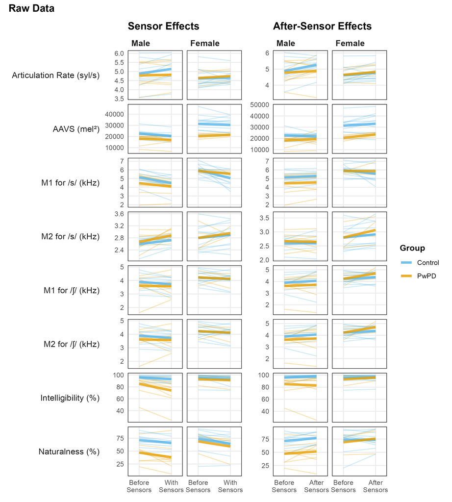

Figure S1: Individual raw data across the target measures.

## Tables

### Table S1

|  | Group | Age | Time Since Diagnosis (years) | Severity<sup>1</sup> |
| --- | --- | --- | --- | --- |
| Male Speakers |  |  |  |  |
| PDM01 | PD | 60 |  | Profound |
| PDM02 | PD | 80 |  | Profound |
| PDM03 | PD | 50 |  | Mild |
| PDM04 | PD | 79 |  | Severe |
| PDM05 | PD | 65 |  | Moderate |
| PDM06 | PD | 82 |  | Moderate |
| PDM07 | PD | 78 |  | Severe |
| PDM08 | PD | 82 |  | Moderate |
| PDM09 | PD | 74 |  | Moderate |
| n | 9 | — | — | — |
| M | — | 72.22 | — | — |
| SD | — | 11.34 | — | — |
| Female Speakers |  |  |  |  |
| PDF01 | PD | 80 |  | Mild |
| PDF02 | PD | 61 |  | Severe |
| PDF03 | PD | 63 |  | Moderate |
| PDF04 | PD | 69 |  | Mild |
| n | 4 | — | — | — |
| M | — | 68.25 | — | — |
| SD | — | 8.54 | — | — |
| N | 13 | — | — | — |
| Total M | — | 71.00 | — | — |
| Total SD | — | 10.38 | — | — |

<sup>1</sup> Severity labels were previously determined by Thompson & Kim (2024) based on the intelligibility measures using the surrogate-severity measures outlined in Stipancic et al. (2022). Specifically, intelligibility values > 94% are `Normal`, 85% - 94% are `Mild`, 70% - 84% are `Moderate`, 45% - 69% are `Severe`, and < 45% are `Profound`.

Table S1: Speaker demographics for the speakers with Parkinson’s disease.

### Table S2

|  | Group | Age |
| --- | --- | --- |
| Male Speakers |  |  |
| CM01 | Control | 49 |
| CM02 | Control | 51 |
| CM03 | Control | 85 |
| CM04 | Control | 47 |
| CM05 | Control | 68 |
| CM06 | Control | 70 |
| CM07 | Control | 53 |
| CM08 | Control | 74 |
| CM09 | Control | 81 |
| n | 9 | — |
| M | — | 64.22 |
| SD | — | 14.52 |
| Female Speakers |  |  |
| CF01 | Control | 66 |
| CF02 | Control | 67 |
| CF03 | Control | 54 |
| CF04 | Control | 68 |
| CF05 | Control | 56 |
| CF06 | Control | 68 |
| CF07 | Control | 65 |
| CF08 | Control | 49 |
| CF09 | Control | 65 |
| CF10 | Control | 72 |
| CF11 | Control | 76 |
| CF12 | Control | 67 |
| n | 12 | — |
| M | — | 64.42 |
| SD | — | 7.69 |
| N | 21 | — |
| Total M | — | 64.33 |
| Total SD | — | 10.81 |

Table S2: Speakers demographics for the control speakers.

### Table S3

| **Characteristic** | **N = 79**<sup>1</sup> |
| --- | --- |
| Age | 20.62 (0.96) |
| Gender |  |
| Woman | 79 (100%) |
| Race |  |
| Asian American | 3 (4%) |
| Biracial or Multiracial | 3 (4%) |
| Black/African American | 1 (1%) |
| Prefer not to say | 1 (1%) |
| White/Caucasian | 71 (90%) |
| Ethnicity |  |
| Hispanic/Latino | 13 (16%) |
| Not Hispanic/Latino | 64 (81%) |
| Prefer not to say | 2 (3%) |

<sup>1</sup> Mean (SD); n (%)

Table S3: Listener demographics.

### Table S4

| Predictors | Articulation Rate (syl/s) Estimates | Articulation Rate (syl/s) pd | Articulation Rate (syl/s) CI (95%) | AAVS (log of mel<sup>2</sup>) Estimates | AAVS (log of mel<sup>2</sup>) pd | AAVS (log of mel<sup>2</sup>) CI (95%) |
| --- | --- | --- | --- | --- | --- | --- |
| Fixed Effects |  |  |  |  |  |  |
| Intercept (Control × Before Sensors) | 6.04 | 1.00 | 4.79 – 7.26 | 10.23 | 1.00 | 9.44 – 11.01 |
| PwPD | .04 | .57 | -.39 – .46 | -.29 | 1.00 | -.48 – -.08 |
| Female | -.33 | .95 | -.71 – .06 | .31 | 1.00 | .14 – .49 |
| Age | -.02 | .97 | -.04 – .001 | -.003 | .73 | -.01 – .01 |
| Articulation Rate |  |  |  | -.01 | .58 | -.10 – .08 |
| Control × With Sensors | .14 | .98 | .01 – .26 | -.06 | .96 | -.12 – .01 |
| PwPD × With Sensors | -.07 | .76 | -.27 – .13 | .03 | .74 | -.07 – .14 |
| Control × After Sensors | .24 | 1.00 | .12 – .37 | .01 | .65 | -.05 – .08 |
| PwPD × After Sensors | -.10 | .84 | -.31 – .10 | .09 | .96 | -.01 – .19 |
| Random Effects |  |  |  |  |  |  |
| σ<sup>2</sup> | .126 |  |  | .103 |  |  |
| N<sub>SpeakerID</sub> | 34 |  |  | 34 |  |  |
| N<sub>SpeakerID/Phrase</sub> | 102 |  |  |  |  |  |
| Summary |  |  |  |  |  |  |
| Observations | 305 |  |  | 102 |  |  |
| Bayesian R<sup>2</sup> | .798 |  |  | .905 |  |  |

Table S4: *Note.* PwPD = People with Parkinson’s disease

### Table S5

| Predictors | M1 for /s/ (kHz) Estimates | M1 for /s/ (kHz) pd | M1 for /s/ (kHz) CI (95%) | M1 for /ʃ/ (kHz) Estimates | M1 for /ʃ/ (kHz) pd | M1 for /ʃ/ (kHz) CI (95%) |
| --- | --- | --- | --- | --- | --- | --- |
| Fixed Effects |  |  |  |  |  |  |
| Intercept (Control × Before Sensors) | 7.07 | 1.00 | 4.47 – 9.73 | 6.59 | 1.00 | 4.32 – 8.92 |
| PwPD | -.30 | .83 | -.93 – .31 | -.05 | .57 | -.56 – .48 |
| Female | .80 | 1.00 | .27 – 1.33 | .36 | .94 | -.11 – .81 |
| Age | -.03 | .99 | -.06 – -.004 | -.02 | .97 | -.04 – 3e-04 |
| Articulation Rate | -.003 | .51 | -.34 – .34 | -.29 | .97 | -.59 – .01 |
| Control × With Sensors | -.80 | 1.00 | -1.08 – -.52 | -.11 | .83 | -.33 – .12 |
| PwPD × With Sensors | .43 | .97 | -.02 – .88 | .06 | .63 | -.29 – .42 |
| Control × After Sensors | -.16 | .86 | -.44 – .14 | .21 | .96 | -.03 – .45 |
| PwPD × After Sensors | .22 | .83 | -.24 – .67 | .05 | .60 | -.31 – .41 |
| Random Effects |  |  |  |  |  |  |
| σ<sup>2</sup> | .206 |  |  | .144 |  |  |
| N<sub>SpeakerID</sub> | 34 |  |  | 34 |  |  |
| Summary |  |  |  |  |  |  |
| Observations | 102 |  |  | 103 |  |  |
| Bayesian R<sup>2</sup> | .799 |  |  | .745 |  |  |

Table S5: *Note.* PwPD = People with Parkinson’s disease

### Table S6

| Predictors | M2 for /s/ (kHz) Estimates | M2 for /s/ (kHz) pd | M2 for /s/ (kHz) CI (95%) | M2 for /ʃ/ (kHz) Estimates | M2 for /ʃ/ (kHz) pd | M2 for /ʃ/ (kHz) CI (95%) |
| --- | --- | --- | --- | --- | --- | --- |
| Fixed Effects |  |  |  |  |  |  |
| Intercept (Control × Before Sensors) | 2.22 | 1.00 | 1.10 – 3.31 | 6.55 | 1.00 | 4.34 – 8.78 |
| PwPD | .06 | .70 | -.18 – .31 | -.05 | .59 | -.55 – .46 |
| Female | .24 | .99 | .03 – .46 | .35 | .94 | -.09 – .80 |
| Age | -3e-04 | .53 | -.01 – .01 | -.02 | .97 | -.04 – 3e-05 |
| Articulation Rate | .08 | .86 | -.07 – .23 | -.28 | .97 | -.58 – .004 |
| Control × With Sensors | .10 | .96 | -.02 – .23 | -.11 | .83 | -.34 – .11 |
| PwPD × With Sensors | .09 | .83 | -.10 – .28 | .07 | .64 | -.29 – .43 |
| Control × After Sensors | .05 | .79 | -.08 – .18 | .21 | .96 | -.02 – .44 |
| PwPD × After Sensors | .01 | .52 | -.19 – .20 | .05 | .60 | -.30 – .41 |
| Random Effects |  |  |  |  |  |  |
| σ<sup>2</sup> | .039 |  |  | .022 |  |  |
| N<sub>SpeakerID</sub> | 34 |  |  | 34 |  |  |
| Summary |  |  |  |  |  |  |
| Observations | 102 |  |  | 103 |  |  |
| Bayesian R<sup>2</sup> | .675 |  |  | .744 |  |  |

Table S6: *Note.* PwPD = People with Parkinson’s disease

### Table S7

[output not shown]

Table S7: *Note.* PwPD = People with Parkinson’s disease